# DS7333 Final Case Study

# Cost Analysis of an Unknown Dataset

Martin Garcia, Michael Catalano, Jeremy Otsap, Christian Nava  
August 12, 2020

## Introduction

We have been presented with a dataset of 160,000 rows and 51 columns. The columns are labeled y, and x0 through x49. The objective is to predict the values of the target variable, y, which has values of 0 and 1. False positives have a cost of $10 each and false negatives have a cost of $500 each. True positives and true negatives have a cost of $0.

```r
# loading data file from Azure Blob Storage as it exceeds the size threshold for github
final.df <- read.csv("https://modisdatawu2sqlml01.blob.core.windows.net/smu-data/ds7333/final_project.csv", header = T)
```

```r
#examine data
str(final.df)
```

```
'data.frame':   160000 obs. of  51 variables:
 $ x0 : num  -0.167 -0.15 -0.322 -0.246 -0.273 ...
 $ x1 : num  -3.962 -0.586 -1.43 5.077 0.306 ...
 $ x2 : num  4.62 27.84 12.25 -24.15 -11.35 ...
 $ x3 : num  2.48 4.15 6.59 3.64 1.68 ...
 $ x4 : num  -1.8 6.43 -5.3 6.51 2.93 ...
 $ x5 : num  0.805 -2.427 -11.311 2.29 -0.617 ...
 $ x6 : num  6.72 40.48 17.81 -35.11 -16.51 ...
 $ x7 : num  -14.79 -6.73 11.06 -18.91 27.53 ...
 $ x8 : num  -1.041 0.896 5.326 -0.337 1.2 ...
 $ x9 : num  -4.2 0.33 -2.63 -5.57 -4.31 ...
 $ x10: num  6.19 -11.71 1.57 -2 6.67 ...
 $ x11: num  13.25 -2.35 -4.17 -19.29 1.97 ...
 $ x12: num  25.7 -25 12.1 11 -28.1 ...
 $ x13: num  -5.02 9.8 -5.16 -5.91 -1.26 ...
```

[output cut: 37 more lines]

```r
summary(final.df)
```

```
       x0                  x1                   x2                x3
 Min.   :-1.592635   Min.   :-26.278302   Min.   :-59.394   Min.   :-35.47659
 1st Qu.:-0.251641   1st Qu.: -4.260973   1st Qu.:-10.167   1st Qu.: -5.45444
 Median :-0.002047   Median :  0.004813   Median : -1.341   Median : -0.03141
 Mean   :-0.001028   Mean   :  0.001358   Mean   : -1.150   Mean   : -0.02464
 3rd Qu.: 0.248532   3rd Qu.:  4.284220   3rd Qu.:  7.872   3rd Qu.:  5.44518
 Max.   : 1.600849   Max.   : 27.988178   Max.   : 63.546   Max.   : 38.90603
 NA's   :26          NA's   :25           NA's   :38        NA's   :37
       x4                   x5                  x6                x7
 Min.   :-28.467536   Min.   :-33.82299   Min.   :-86.354   Min.   :-181.507
 1st Qu.: -4.313118   1st Qu.: -5.14813   1st Qu.:-14.780   1st Qu.: -27.325
 Median :  0.000857   Median :  0.01412   Median : -1.949   Median :  -6.957
 Mean   : -0.000549   Mean   :  0.01358   Mean   : -1.671   Mean   :  -7.693
 3rd Qu.:  4.306660   3rd Qu.:  5.19075   3rd Qu.: 11.447   3rd Qu.:  12.217
 Max.   : 26.247812   Max.   : 35.55011   Max.   : 92.391   Max.   : 149.151
 NA's   :26           NA's   :37          NA's   :26        NA's   :27
       x8                  x9                  x10
 Min.   :-37.69105   Min.   :-27.980659   Min.   :-36.30657
 1st Qu.: -6.03106   1st Qu.: -4.260619   1st Qu.: -5.28820
 Median : -0.01684   Median :  0.006045   Median : -0.01818
 Mean   : -0.03054   Mean   :  0.005462   Mean   :  0.00225
 3rd Qu.:  5.97235   3rd Qu.:  4.305734   3rd Qu.:  5.33157
 Max.   : 39.04983   Max.   : 27.377842   Max.   : 37.94558
 NA's   :21          NA's   :30           NA's   :43
      x11                 x12               x13                 x14
 Min.   :-38.09287   Min.   :-64.198   Min.   :-38.72351   Min.   :-30.90521
 1st Qu.: -5.90327   1st Qu.:-11.379   1st Qu.: -6.02995   1st Qu.: -4.69676
 Median :  0.01094   Median : -1.624   Median : -0.00347   Median :  0.00247
 Mean   :  0.03023   Mean   : -1.334   Mean   :  0.00767   Mean   :  0.00810
 3rd Qu.:  5.93503   3rd Qu.:  8.375   3rd Qu.:  6.04196   3rd Qu.:  4.70130
 Max.   : 36.36044   Max.   : 73.279   Max.   : 42.39218   Max.   : 32.54634
 NA's   :30          NA's   :36        NA's   :31          NA's   :34
      x15                 x16                  x17
 Min.   :-17.00236   Min.   :-26.042983   Min.   :-34.39590
 1st Qu.: -2.20777   1st Qu.: -3.344027   1st Qu.: -5.07147
 Median :  0.00354   Median :  0.012754   Median :  0.02454
 Mean   :  0.00121   Mean   :  0.006223   Mean   :  0.01204
 3rd Qu.:  2.21166   3rd Qu.:  3.366853   3rd Qu.:  5.10196
 Max.   : 13.78256   Max.   : 21.961123   Max.   : 37.05705
 NA's   :35          NA's   :26           NA's   :27
```

[output cut: 56 more lines]

```
      x46               x47                 x48                x49
 Min.   :-201.83   Min.   :-21.08633   Min.   :-8.49016   Min.   :-65.7912
 1st Qu.: -36.43   1st Qu.: -3.21602   1st Qu.:-1.32080   1st Qu.:-10.9317
 Median : -12.98   Median :  0.03587   Median :-0.01199   Median : -0.5744
 Mean   : -12.76   Mean   :  0.02862   Mean   :-0.00022   Mean   : -0.6742
 3rd Qu.:  11.45   3rd Qu.:  3.26803   3rd Qu.: 1.31770   3rd Qu.:  9.6511
 Max.   : 150.86   Max.   : 20.83685   Max.   : 8.22655   Max.   : 66.8776
 NA's   :31        NA's   :37          NA's   :32         NA's   :32
       y
 Min.   :0.0000
 1st Qu.:0.0000
 Median :0.0000
 Mean   :0.4012
 3rd Qu.:1.0000
 Max.   :1.0000
```

## Data Exploration

An initial review of the data reveals all but five variables are numeric. The remaining variables are categorical and can be most aptly described or labled as country (x24), month (x29), day_of_the_week (x30). Variables x32 and x37 appear to be a percentage change and a dollar amount, respectively. These are being mislabeled as factor variables due to the $ and % characters. In order to correctly analyze these columns we converted these to numeric values.

```r
# convert percentage factor to numeric
as.numeric(gsub("\\%","",final.df$x32)) -> final.df$x32

# convert dollar factor to numeric
as.numeric(gsub("\\$","",final.df$x37)) -> final.df$x37

# validate x32 and x37 are now numeric
str(final.df[,c(33,38)])
```

```
'data.frame':   160000 obs. of  2 variables:
 $ x32: num  0 -0.02 -0.01 0.01 0.01 -0.01 -0.01 0.01 -0.03 0.01 ...
 $ x37: num  1314 1963 430 -2366 -621 ...
```

We used PowerBI to perform some data exploration and get a sense of the data. We found that the response variable is sensitive to summer months as can be seen in Figure 1.

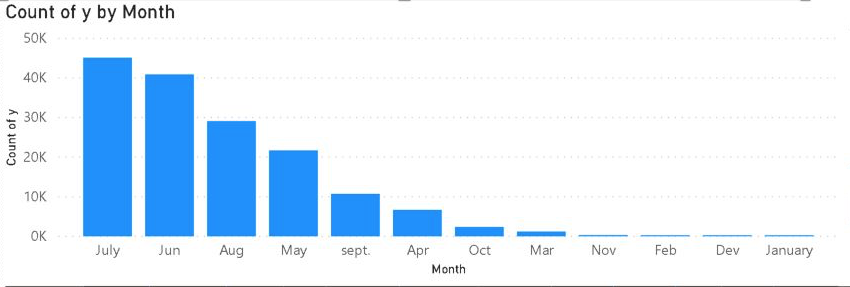

Additionally, most of the dollar value appears to come from Europe as can be seen in Figure 2. Whether that dollar value is an expense or revenue is unclear.

#### Figure 2: Dollars by Country

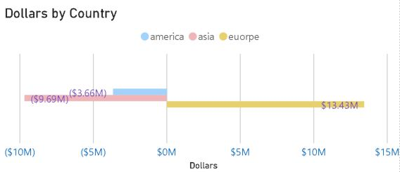

When we look at percent change by country, we see the largest percent change comes from Europe as shown is Figure 3.

#### Figure 3: Percent Change by Country

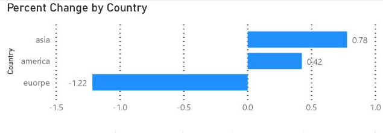

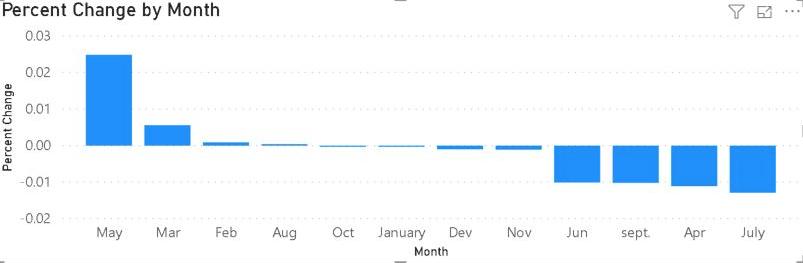

An initial inspection leads us to believe variable x37, which is a dollar amount, may be an influential variable.

## Missing Data: Imputation Method

We find that all columns except for the categorial columns have observations with missing values.

```r
# check variables for missing values
sapply(final.df, function(x) sum(is.na(x)))
```

```
 x0  x1  x2  x3  x4  x5  x6  x7  x8  x9 x10 x11 x12 x13 x14 x15 x16 x17 x18 x19
 26  25  38  37  26  37  26  27  21  30  43  30  36  31  34  35  26  27  40  35
x20 x21 x22 x23 x24 x25 x26 x27 x28 x29 x30 x31 x32 x33 x34 x35 x36 x37 x38 x39
 38  29  27  47   0  22  36  30  35   0   0  39  31  41  41  30  27  23  31  23
x40 x41 x42 x43 x44 x45 x46 x47 x48 x49   y
 36  40  26  37  40  29  31  37  32  32   0
```

A visualizaiton of the missing data shows that each column has its own unique set of missing values, which do not align to other columns/parameters. Dropping rows with missing variables, or using listwise deletion, would delete an entire row for that column’s one missing value.

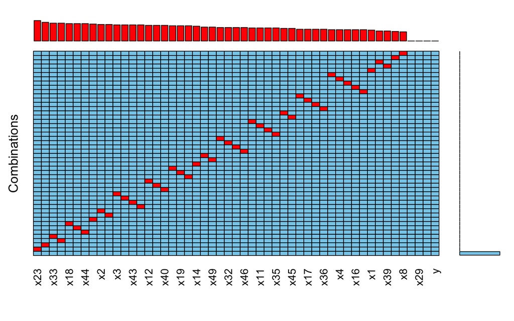

```
 Variables sorted by number of missings:
 Variable Count
      x23    47
      x10    43
      x33    41
      x34    41
      x18    40
      x41    40
      x44    40
      x31    39
       x2    38
      x20    38
       x3    37
       x5    37
      x43    37
      x47    37
      x12    36
      x26    36
      x40    36
      x15    35
      x19    35
      x28    35
      x14    34
      x48    32
      x49    32
      x13    31
      x32    31
      x38    31
      x46    31
       x9    30
      x11    30
      x27    30
      x35    30
      x21    29
      x45    29
       x7    27
      x17    27
      x22    27
      x36    27
       x0    26
       x4    26
       x6    26
      x16    26
      x42    26
       x1    25
      x37    23
      x39    23
      x25    22
       x8    21
      x24     0
      x29     0
      x30     0
        y     0
```

```r
# visualize missing data
aggr(final.df,
     prop = FALSE,
     combined = TRUE,
     numbers = TRUE,
     sortVars = TRUE,
     sortCombs = TRUE)
```

### Listwise Deletion

Given that many variables have observations with missing values, a listwise deletion approach would maximize data loss, resulting in 1,520 deleted rows, or approximately 0.95% data loss.

```r
# output number of missing rows
print("total number of deleted rows: ")
```

```
[1] "total number of deleted rows: "
```

```r
print(dim(final.df)[1] - dim(na.omit(final.df))[1] )
```

```
[1] 1520
```

```r
# apply listwise deletion to new dataframe
final_impute.df <- na.omit(final.df)

print( "The percentage difference for listwise deletion is: "  )
```

```
[1] "The percentage difference for listwise deletion is: "
```

```r
print( (nrow(final.df)-nrow(final_impute.df))/nrow(final.df) )
```

```
[1] 0.0095
```

### Final Imputation Approach

Wee used a hybrid approach of mean substituion and listwise deletion for data imputation. Missing categorical observations would be dropped and missing numerical values would be replaced with the mean value of the variable.

We confirmed there were no missing values on the categorical columns x24, x29, and x30, which do not require an imputation method.

```r
# output number of remaining rows after applying listwise deletion
print("total number of missing rows in X24: ")
```

```
[1] "total number of missing rows in X24: "
```

```r
sum(is.na(final.df$x24))
```

```
[1] 0
```

```r
print("total number of missing rows in X29: ")
```

```
[1] "total number of missing rows in X29: "
```

```r
sum(is.na(final.df$x29))
```

```
[1] 0
```

```r
print("total number of missing rows in X30: ")
```

```
[1] "total number of missing rows in X30: "
```

```r
sum(is.na(final.df$x30))
```

```
[1] 0
```

We than used mean subsitutionn for the missing numerical values.

```r
# create new dataframe
final.df -> final_msub.df

# loop through na.mean
loop_length <- length(final_msub.df)

for (i in c(1:24,26:29,32:51) ) {
  na.mean(final_msub.df[,i]) -> final_msub.df[,i]
  i = i + 1
}
```

We then verified new imputed dataframe had no missing values and the factor data types had not changed.

```r
# verify x24, x29, and x30 are still categorical
str(final_msub.df[,c(25, 30, 31)])
```

```
'data.frame':   160000 obs. of  3 variables:
 $ x24: Factor w/ 4 levels "","america","asia",..: 4 3 3 3 3 3 3 3 3 3 ...
 $ x29: Factor w/ 13 levels "","Apr","Aug",..: 7 3 7 7 7 3 8 3 10 8 ...
 $ x30: Factor w/ 6 levels "","friday","monday",..: 5 6 6 6 5 6 6 6 6 6 ...
```

```r
# verify all missing values have been imputd
sapply(final_msub.df, function(x) sum(is.na(x)))
```

```
 x0  x1  x2  x3  x4  x5  x6  x7  x8  x9 x10 x11 x12 x13 x14 x15 x16 x17 x18 x19
  0   0   0   0   0   0   0   0   0   0   0   0   0   0   0   0   0   0   0   0
x20 x21 x22 x23 x24 x25 x26 x27 x28 x29 x30 x31 x32 x33 x34 x35 x36 x37 x38 x39
  0   0   0   0   0   0   0   0   0   0   0   0   0   0   0   0   0   0   0   0
x40 x41 x42 x43 x44 x45 x46 x47 x48 x49   y
  0   0   0   0   0   0   0   0   0   0   0
```

A visualization of the data gives us additional confirmation of that the missing data has been replaced.

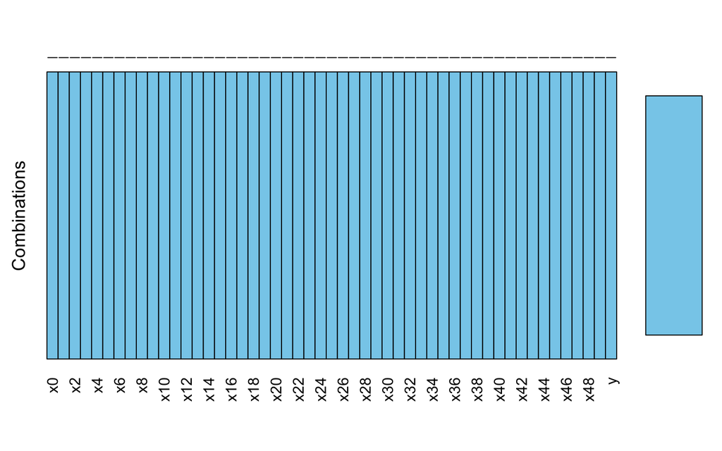

```
 Variables sorted by number of missings:
 Variable Count
       x0     0
       x1     0
       x2     0
       x3     0
       x4     0
       x5     0
       x6     0
       x7     0
       x8     0
       x9     0
      x10     0
      x11     0
      x12     0
      x13     0
      x14     0
      x15     0
      x16     0
      x17     0
      x18     0
      x19     0
      x20     0
      x21     0
      x22     0
      x23     0
      x24     0
      x25     0
      x26     0
      x27     0
      x28     0
      x29     0
      x30     0
      x31     0
      x32     0
      x33     0
      x34     0
      x35     0
      x36     0
      x37     0
      x38     0
      x39     0
      x40     0
      x41     0
      x42     0
      x43     0
      x44     0
      x45     0
      x46     0
      x47     0
      x48     0
      x49     0
        y     0
```

```r
# visualize missing data
aggr(final_msub.df,
     prop = FALSE,
     combined = TRUE,
     numbers = TRUE,
     sortVars = TRUE,
     sortCombs = TRUE)
```

## Data Visualization

Using a box plot of each variable, we can see that variable x37 has a much larger range than the other variables. Variable x37 was a dollar ammount.

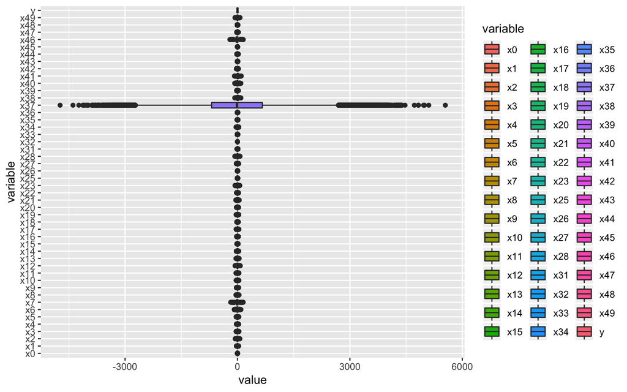

To bring this variable’s value within range of the other variables we can perform scaling and centering, or we can divide by 1,000 to represent thousands of dollars. We chose to divide variable x37’s value by 1,000.

```r
# compare range of x37 raw and divided by 1000
summary(final_msub.df$x37)
```

```
     Min.   1st Qu.    Median      Mean   3rd Qu.      Max.
-4734.540  -691.173   -13.505     0.378   664.107  5546.990
```

```r
summary((final_msub.df$x37)/1000)
```

```
     Min.   1st Qu.    Median      Mean   3rd Qu.      Max.
-4.734540 -0.691172 -0.013505  0.000378  0.664108  5.546990
```

The data has now been prepared for modeling and analysis.

## Performance Metric: AUC Score

The metric used for this project is the area under the Receiver Operating Characteristic curve (AUC). The Receiver Operating Characteristic curve (ROC) graphs the performance of a classification model at all classification thresholds; it plots the true positive rate (TPR) against the false positive rate (FPR) as shown in Figure 1.

#### Figure 1: Area Under the Reciever Operating Curve

[figure not shown]

#### Source: Journal of Thoracic and Cardiovascular Surgery

Each curve represents the graph of a single model. Movement along the curve indicates changing the threshold used for classifying a positive instance. The area under the ROC curve measures the two-dimensional area under the ROC curve and is given by the integral of the curve, or the area under the curve (AUC):
$$AUC = \int_{0}^{1}TPR(x)dx = \int_{0}^{1}P(A>\tau (x))dx$$

where $x$ is the false positive rate and $A$ is the distribution of scores the model produces for data points that are actually in the positive class.

This metric is measured between 0 and 1. A higher score indicates a better model. Visually, a superior model will graph as a curve above and to the left of another curve. A straight diagonal line beginning at 0 on the bottom left and ending at 1 on the top right indicates a naive model (random guessing).

## Outline of Approach

A logistic regression model was used as a baseline, or benchmark, model and the results were then compared to those from an untuned random forest model, a tuned random forest model, and a feed-forward neural network model, and a feed-forward neural network model using the most important variables as per the random forest model.

## Model 1: Logistic Regression

Logistic regression is a method to estimate the probability of a binary response based on one or more independent variables. It aims to model the conditional probabilty $P(Y=1|X=x)\,$ as a function of $x$. The probabilities, however, must be bounded by $0$ and $1$. To acheive this, a logistic (or logit) transformation, $\;log\frac{p(x)}{1-p(x)}$, is applied [1]. The resulting regression model takes on the form
$$log\frac{p(x)}{1-p(x)}=\beta{_0}+\beta{_x}\cdot{x}$$
where $1-p(x)\,$ is the probability that $Y=0$, $\;p(x)$ is the probability that $Y=1$, $\;\beta{_0}$ is the intercept from the linear regression equation, $\;\beta{_x}$is the regression coefficient, and $x$ is an independent variable (predictor). Misclassification is minimized by predicting $Y=1$ when $\,p\geq0.5\,$, and $Y=0\,$ when $p\leq0.5\;$ (i.e., choosing $1$ when $\beta{_0}+\beta{_x}\cdot{x}\;$ is non-negative and $0$ otherwise).

We used the caret package, and for the caret package to properly process binomial classification models, the response must be categorical binary.

```r
# categorize y
final_msub.df <- final_msub.df %>% mutate(y = factor(y) )
```

We begin by creating a training and test set. There is a slight imbalance in the response variable, and we want to ensure that the sampled proportion of positive and negative classes in the data set is represented in the training and test sets.

```r
# plot classes for y variable
#final.df %>%
 # ggplot(aes(x=y)) +
  #geom_col()
```

The `caret` package automatically does this by splitting the sample into groups sections based on percentiles and sampling is done within these subgroups.

```r
set.seed(123)
# creating the 80 data partition
final_split <- createDataPartition(final_msub.df$y, p = 0.8, list = F)
# including 80 for training set
final_train.df <- final_msub.df[final_split,]
# excluding 80 for testing set
final_test.df <- final_msub.df[-final_split,]
# validating
dim(final_test.df)
```

```
[1] 31999    51
```

```r
dim(final_train.df)
```

```
[1] 128001     51
```

```r
# compare level split of main data frame
table(final_msub.df$y)
```

```
    0     1
95803 64197
```

```r
# validating sample maintained ratio for response levels
table(final_test.df$y)
```

```
    0     1
19160 12839
```

```r
table(final_train.df$y)
```

```
    0     1
76643 51358
```

### Baseline Model

For the baseline model, we did not tune any hyperparameters or perform feature selection.

```r
# create logistic regression model on train data
# R will automatically create dummy variables on factors
ptm <- proc.time()
final_train.logit <- glm(y ~ ., data = final_train.df, family = binomial("logit") )
summary(final_train.logit)
```

```
Call:
glm(formula = y ~ ., family = binomial("logit"), data = final_train.df)

Deviance Residuals:
    Min       1Q   Median       3Q      Max
-2.6654  -0.8646  -0.5958   1.0298   3.4041

Coefficients:
               Estimate Std. Error z value Pr(>|z|)
(Intercept)   4.245e-01  8.177e-01   0.519  0.60363
x0            4.013e-03  1.706e-02   0.235  0.81400
x1            1.434e-03  1.002e-03   1.431  0.15236
x2           -1.931e-02  2.367e-02  -0.816  0.41448
x3            5.278e-04  7.862e-04   0.671  0.50200
x4            1.129e-03  9.933e-04   1.137  0.25571
x5           -7.728e-06  8.274e-04  -0.009  0.99255
x6           -2.377e-02  1.734e-02  -1.371  0.17042
x7            5.110e-03  1.039e-02   0.492  0.62298
x8           -1.350e-03  7.120e-04  -1.896  0.05800 .
x9            8.744e-04  9.961e-04   0.878  0.38003
x10          -2.468e-04  8.052e-04  -0.307  0.75920
x11          -1.744e-04  7.219e-04  -0.242  0.80914
x12          -1.115e-02  1.491e-02  -0.748  0.45454
x13          -2.690e-04  7.091e-04  -0.379  0.70446
x14          -1.173e-03  9.102e-04  -1.289  0.19752
x15           9.631e-04  1.941e-03   0.496  0.61975
x16           2.314e-03  1.274e-03   1.817  0.06924 .
x17          -1.187e-03  8.366e-04  -1.419  0.15586
x18           2.329e-03  1.396e-03   1.668  0.09524 .
x19           3.050e-04  8.347e-04   0.365  0.71480
x20          -2.266e-02  2.696e-02  -0.841  0.40058
x21           6.423e-04  6.731e-04   0.954  0.34001
x22           9.679e-04  1.173e-03   0.825  0.40912
x23          -2.507e-02  1.214e-02  -2.065  0.03890 *
x24america   -5.710e-01  4.389e-01  -1.301  0.19327
x24asia      -3.656e-01  4.365e-01  -0.838  0.40220
x24euorpe    -3.684e-01  4.371e-01  -0.843  0.39937
x25           5.376e-03  5.009e-03   1.073  0.28315
x26          -6.028e-03  7.515e-03  -0.802  0.42254
x27           1.545e-02  3.415e-02   0.452  0.65105
```

[output cut: 32 more lines]

```
x45          -6.788e-03  1.597e-02  -0.425  0.67077
x46          -5.743e-04  9.495e-03  -0.060  0.95177
x47           1.145e-03  1.323e-03   0.865  0.38680
x48          -2.025e-01  6.335e-02  -3.196  0.00139 **
x49           3.009e-02  1.615e-02   1.864  0.06235 .
---
Signif. codes:  0 '***' 0.001 '**' 0.01 '*' 0.05 '.' 0.1 ' ' 1

(Dispersion parameter for binomial family taken to be 1)

    Null deviance: 172419  on 128000  degrees of freedom
Residual deviance: 146564  on 127933  degrees of freedom
AIC: 146700

Number of Fisher Scoring iterations: 4
```

```r
proc.time() - ptm
```

```
   user  system elapsed
  3.745   0.336   4.155
```

Visualizing the coefficients of the full logistic model, we can see the most influential variables are x32, x29January, and x24america.

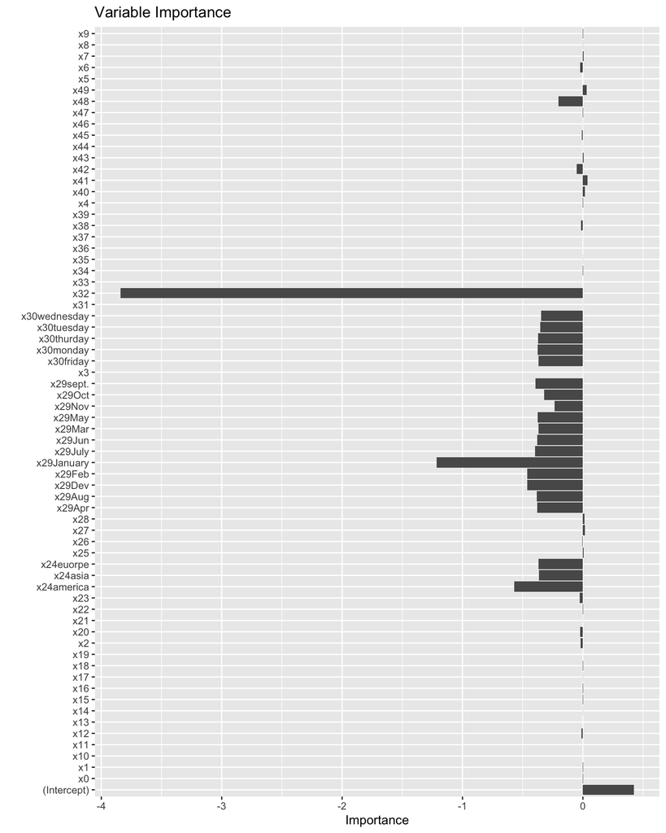

```r
# visualize coefficients
as.data.frame(final_train.logit$coefficients) %>%
  ggplot(aes(y = .[,1], x = rownames(.)) ) + geom_bar(stat = 'identity') + coord_flip() + ylab("Importance") + xlab("") + ggtitle("Variable Importance") + guides(fill=F) + scale_fill_gradient(low="gray", high="blue")
```

#### ROC Curve for Full Logistic Model

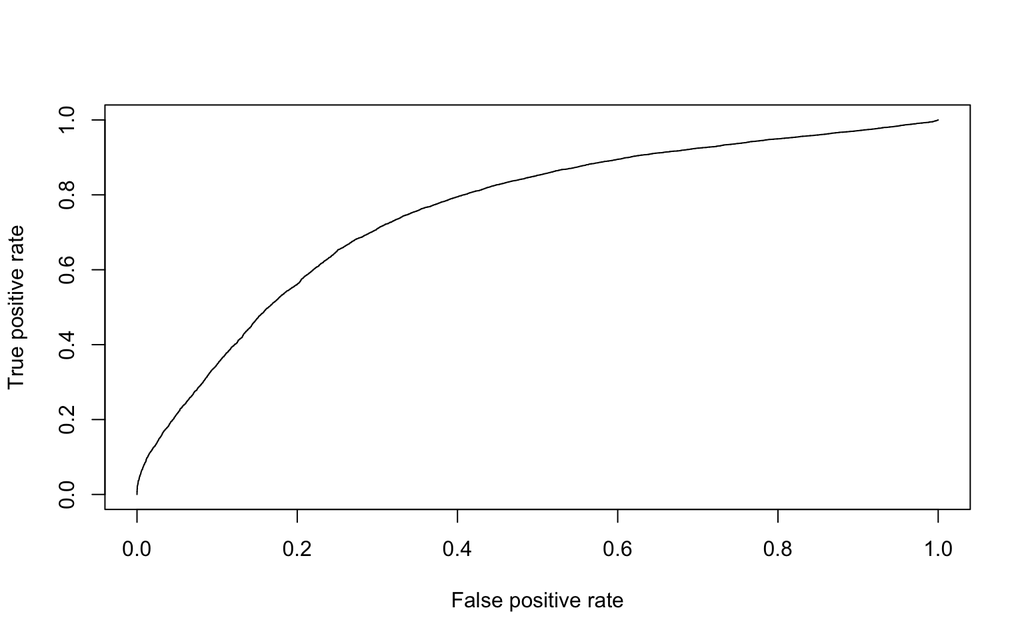

```r
# create predictions
predict(
  final_train.logit,
  newdata = final_test.df,
  type = "response"
  ) -> final_logit.pred

# ROC curve
performance(
  ROCR::prediction(final_logit.pred, final_test.df$y),
  measure = "tpr",
  x.measure = "fpr"
) -> final_logit.perf

plot(final_logit.perf)
```

```r
# AUC value
print("AUC Value for this model is ")
```

```
[1] "AUC Value for this model is "
```

```r
performance(
  ROCR::prediction(final_logit.pred, final_test.df$y),
  measure = "auc"
)@y.values[[1]]
```

```
[1] 0.7564295
```

#### Confusion Matrix

To ensure we correctly interpret the confusion matrix we explicity specify 1 as the reference and positive class. Additionally, we coerced the probabilities to either be 1 or 0 based on a 50% threshold. The confusion matrix will let us know how many observations were correctly classified as either 0 or 1. It will also indicate how many obervations were incorrectly classified as positives (false positives) and how many were incorrectly classified as negatives (false negatives).

```r
# split into "1" and "0" factors based on 0.5 thresdshold
as.numeric(final_logit.pred > 0.5 ) %>% as.factor() -> final_logit_factor.pred
```

From the confusion matrix we can see that the logistic model has 6,135 false negatives and 3,372 false positives. Since each false positive incurrs a cost of $10 and each false negative costs $500, the total cost of false positives and false negatives is $3,101,220 for the baseline model.

A specificity of 0.82 and sensitivity of 0.52 indicates that this model does a better job of predicting the 0, the negative class, and has almost a 50-50 probability of predicting 1, the positive class.

```r
# confusion matrix
caret::confusionMatrix(
  data = relevel(final_logit_factor.pred, ref = "1"),
  reference = relevel(final_test.df$y , ref = "1")
)
```

```
Confusion Matrix and Statistics

          Reference
Prediction     1     0
         1  6704  3372
         0  6135 15788

               Accuracy : 0.7029
                 95% CI : (0.6979, 0.7079)
    No Information Rate : 0.5988
    P-Value [Acc > NIR] : < 2.2e-16

                  Kappa : 0.3589

 Mcnemar's Test P-Value : < 2.2e-16

            Sensitivity : 0.5222
            Specificity : 0.8240
         Pos Pred Value : 0.6653
         Neg Pred Value : 0.7202
             Prevalence : 0.4012
         Detection Rate : 0.2095
   Detection Prevalence : 0.3149
      Balanced Accuracy : 0.6731

       'Positive' Class : 1
```

## Model 2: Random Forest Model

The random forest model is an ensemble method of learning for classification and is more powerful than logistic regression. The random forest model groups a set of decision trees and then it predicts based on the majority of votes (when used for classification) or aggregation (when used for regression) from each of the decision trees made.

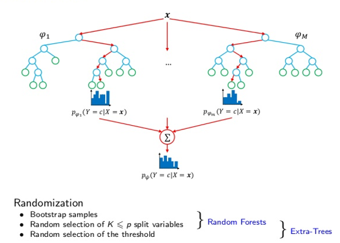

**Figure 1**: Random Forest Model  
Source: [KDNuggets](https://www.kdnuggets.com/2017/10/random-forests-explained.html)

This ensemble method is based on randomization where each tree in the forest is built randomly with the same distribution. Each tree is trained in isolation. The basic procedure for the algorithm involves the following steps illustrated above.

1. Select $\varphi{_M}$ bootstrap samples from the training data, $\chi$.
2. For each of the bootstrap samples $\varphi{_M}$, grow an unpruned classification or regression tree to the largest extent possible (i.e., split the node into two daughter nodes until the minimum node size is reached).
3. Predict new data by aggregating the predictions of the $\varphi{_M}$ trees. These predictions can be assembled into a probability distribution, whose mode (i.e., majority votes for classification) or average (i.e., aggregation for regression) yields the random forest’s proposed rating $p_{\psi}(Y=c|X=\chi)$.

We used the `ranger` package to fit the random forest as opposed to the default `rpart` algorithms or `randomForest` package due to it’s significantly faster C++ implementation that allows for multi-threaded processing.

```r
ptm <- proc.time()

# default mtry for classification is sqrt(# of features)
mtry_final <- floor(sqrt(ncol(final_train.df)))
#tuneGrid = expand.grid(mtry = c(4,5,6))

# training RF model

ranger(
  y ~ .,
  data = final_train.df,
  mtry = mtry_final,
  respect.unordered.factors = "order",
  importance = "permutation", # "impurity",
  verbose = T,
  seed = 665
) -> final_train.rf
proc.time() - ptm
```

```
    user   system  elapsed
1931.499    6.637  528.716
```

Model Hyperparameters for the random forest model include:

- **mtry** How many random variables should be included in each tree?
- **min.node.size** What is minimum depth of each tree before a split can occur?
- **splitrule** What is the criteria to split trees? [i.e. to minimize node impurity]

The `ranger` defaults for the random forest model have not been changed for this model and are listed below:

- mtry for Classification: sqrt(# of predictors) ~7 in this case
- mtry for Regression: (# of predictors) / 3
- min.node.size: 1 for classification or 5 for regression
- splitrule: “gini” for classification or SSE for regression

```r
# confusion matrix on TRAINING data
final_train.rf$confusion.matrix
```

```
    predicted
true     0     1
   0 73326  3317
   1  6121 45237
```

```r
# best tuning parameters
print("Final model's mtry: ")
```

```
[1] "Final model's mtry: "
```

```r
print(final_train.rf$mtry)
```

```
[1] 7
```

```r
print("Final model's min.node.size: ")
```

```
[1] "Final model's min.node.size: "
```

```r
final_train.rf$min.node.size
```

```
[1] 1
```

```r
print("Final model's num.trees: ")
```

```
[1] "Final model's num.trees: "
```

```r
final_train.rf$num.trees
```

```
[1] 500
```

```r
print("Final model's splitrule: ")
```

```
[1] "Final model's splitrule: "
```

```r
final_train.rf$splitrule
```

```
[1] "gini"
```

```r
print("Final model's variable importance mode: ")
```

```
[1] "Final model's variable importance mode: "
```

```r
final_train.rf$importance.mode
```

```
[1] "permutation"
```

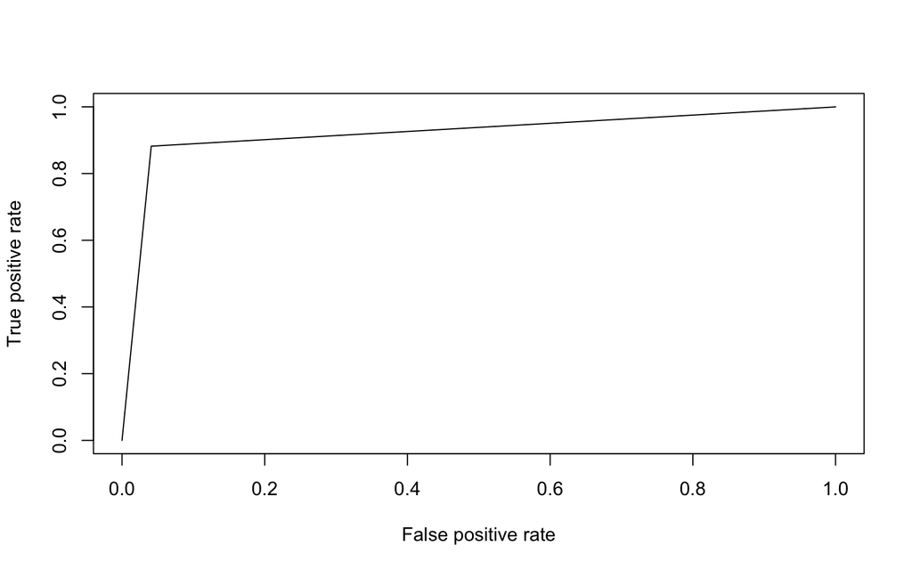

```r
# predictions
predict(
  final_train.rf,
  data = final_test.df,
  ) -> final_forest.pred


# AUC plot
# NOTE: must convert values to numeric to use function
performance(
  ROCR::prediction( as.numeric(final_forest.pred$predictions),
              as.numeric(final_test.df$y) ),
  measure = "tpr",
  x.measure = "fpr"
) -> final_forest.perf
plot(final_forest.perf)
```

```r
# AUC value
print("AUC Value for this model is ")
```

```
[1] "AUC Value for this model is "
```

```r
performance(
  ROCR::prediction( as.numeric(final_forest.pred$predictions),
              as.numeric(final_test.df$y) ),
  measure = "auc",
  )@y.values[[1]]
```

```
[1] 0.9204886
```

The confusion matrix for the random forest model shows 786 false positives yeilding a cost of $7,860 and 1,515 false negatives yeilding a cost of $757,500 or a total cost of $765,360. Additionally, we can see there was a significant improvement in the sensitivity and specificity scores, implying this model does a better job of predicting both the positve and negative classes than the logistic regression model.

```r
# confusion matrix
caret::confusionMatrix(
  data = relevel(final_forest.pred$predictions, ref = "1"),
  reference = relevel(final_test.df$y , ref = "1")
)
```

```
Confusion Matrix and Statistics

          Reference
Prediction     1     0
         1 11324   786
         0  1515 18374

               Accuracy : 0.9281
                 95% CI : (0.9252, 0.9309)
    No Information Rate : 0.5988
    P-Value [Acc > NIR] : < 2.2e-16

                  Kappa : 0.8489

 Mcnemar's Test P-Value : < 2.2e-16

            Sensitivity : 0.8820
            Specificity : 0.9590
         Pos Pred Value : 0.9351
         Neg Pred Value : 0.9238
             Prevalence : 0.4012
         Detection Rate : 0.3539
   Detection Prevalence : 0.3784
      Balanced Accuracy : 0.9205

       'Positive' Class : 1
```

When we look at the variable importance plot, which tells us which variables have the largest effect on the model, we see that variables x23, x49, x20, x48, x42, x37, x12, x40, x27, x6, x2, x28, x41, x38, x7, x46, and x32 have the highest importance.

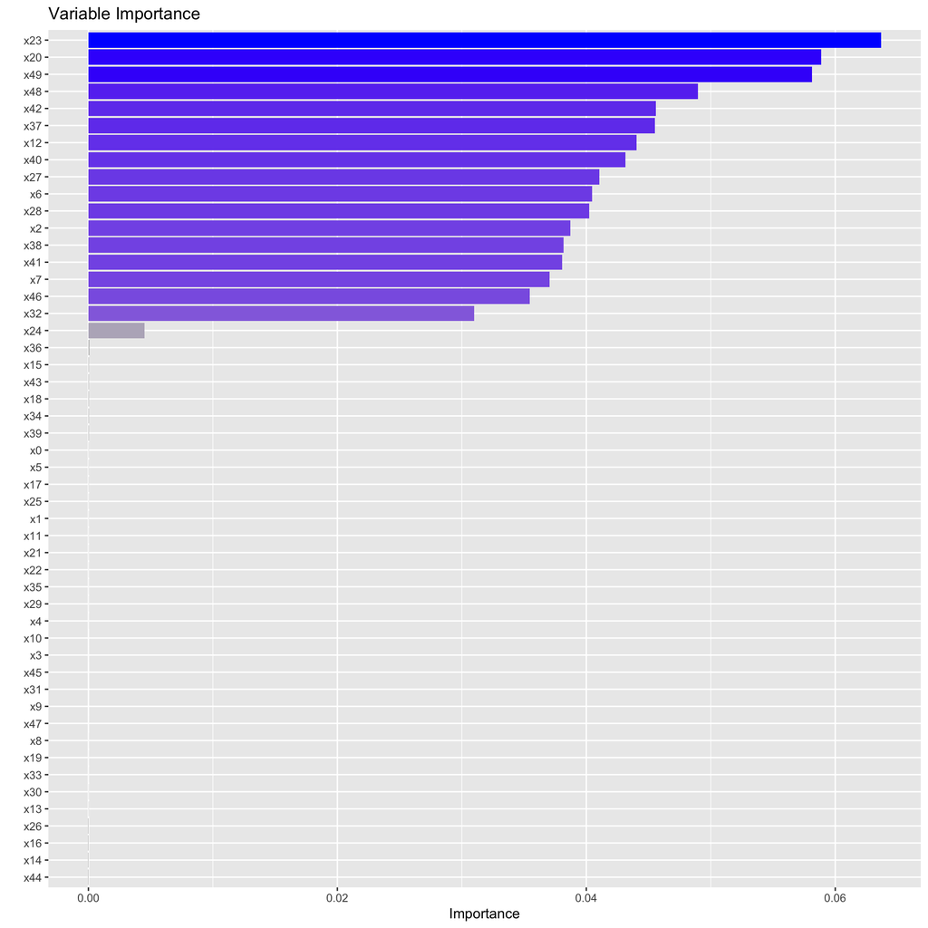

```r
# variable importance plot
final_ranger_imp.df <- as.data.frame(final_train.rf$variable.importance)

# rownames
final_ranger_imp.df$x_label <- rownames(final_ranger_imp.df )

# rename column
names(final_ranger_imp.df)[1] <- "x_value"

# ggplot
ggplot(final_ranger_imp.df, aes(x=reorder(x_label,x_value), y=x_value,fill=x_value)) + geom_bar(stat = 'identity') + coord_flip() + ylab("Importance") + xlab("") + ggtitle("Variable Importance") + guides(fill=F) + scale_fill_gradient(low="gray", high="blue")
```

## Model 3: Tuned Random Forest Model

As per above, there are a number of hyperparameters that can be optimized to improve model performance. We use `caret` as the training engine to optimize Ranger’s hyperparameters as well as executing the 5-fold cross-validation and normalizing the data.

Given the higher cost of false negatives we set the target metric to specificity, rather than the default, accuracy. Specificity measures a model’s abilty to predict true negatives, i.e., when the class is actually negative, how often does the model correctly identify the negative class? If the model was attempting to correctly identify those without cancer, how often did it correctly predict that a patient did not have cancer?

We also set the importance from the default impurity to permutation. Permutation importance is more reliable, albeit more computationally expensive than mean decrease in impurity. The basic idea is to consider a variable important if it has a positive effect on the prediction accuracy (classification), or MSE (regression). This metric is applicable to any model, not just random forests. The risk of using this metric is a potential bias towards collinear predictive variables.

Also reduced the number of trees to 300 from default of 500.

```r
#################################
### TUNED RANDOM FOREST MODEL ###
#################################

# cluster preparation for parallel CPU
library(parallel)
library(doParallel)
cluster <- makeCluster(detectCores() - 1) # leave 1 core for OS
registerDoParallel(cluster)

# start timer to check how long code takes to run
ptm <- proc.time()

# training grid
trainControl(
  method = "cv",
  number = 5,
  summaryFunction = twoClassSummary,
  savePredictions = "final",
  classProbs = F,
  verboseIter = T,
  search = "random",
  allowParallel = T
  ) -> final_caret.grid

# tuning grid

final_tune.grid <- expand.grid(
  mtry = 7,
  splitrule = "extratrees",
  min.node.size = 2)

# training RF model
train(
  y ~ .,
  data = final_train.df,
  method = "ranger",
  trControl = final_caret.grid,
  num.threads = (detectCores() - 1),
  preProcess = c("scale","center"),
  tuneGrid = final_tune.grid,
  num.trees = 300,
  importance = 'permutation', #'impurity',
  metric = "Spec" # "Accuracy" or "Sens"
) -> final_train.caret
# end timer
proc.time() - ptm
```

```
    user   system  elapsed
1059.695    7.522 1703.889
```

```r
### SHUTDOWN CLUSTER
stopCluster(cluster)
#registerDoSEQ()
```

```r
# best tuning parameter
final_train.caret$bestTune
```

```
  mtry  splitrule min.node.size
1    7 extratrees             2
```

```r
#final model
final_train.caret$finalModel
```

```
Ranger result

Call:
 ranger::ranger(dependent.variable.name = ".outcome", data = x,      mtry = min(param$mtry, ncol(x)), min.node.size = param$min.node.size,      splitrule = as.character(param$splitrule), write.forest = TRUE,      probability = classProbs, ...)

Type:                             Classification
Number of trees:                  300
Sample size:                      128001
Number of independent variables:  67
Mtry:                             7
Target node size:                 2
Variable importance mode:         permutation
Splitrule:                        extratrees
Number of random splits:          1
OOB prediction error:             9.96 %
```

```r
# predictions
predict(final_train.caret, final_test.df) -> final_caret.pred
```

The AUC score for the tuned random forest model is 0.8933556.

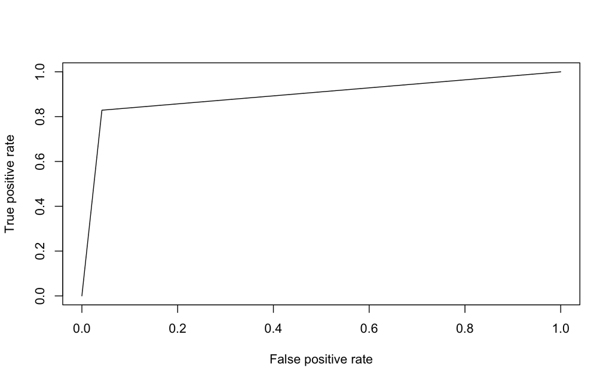

```r
# AUC plot
# NOTE: must convert values to numeric to use function
performance(
  ROCR::prediction( as.numeric(final_caret.pred),
              as.numeric(final_test.df$y)
              ),
  measure = "tpr",
  x.measure = "fpr"
) -> final_caret.perf
plot(final_caret.perf)
```

```r
# AUC value
print("AUC Value for this model is ")
```

```
[1] "AUC Value for this model is "
```

```r
performance(
  ROCR::prediction( as.numeric(final_caret.pred),
              as.numeric(final_test.df$y) ),
  measure = "auc",
  )@y.values[[1]]
```

```
[1] 0.8933556
```

Per the confusion matrix, the tuned random forest model yielded 2,201 false negatives and 802 false positives, for a total cost of $1,108,520. Specifity is 0.9581, which implies that it is correctly classifying the negative class 95.81% of the time.

```r
# confusion matrix
caret::confusionMatrix(
  data = relevel(final_caret.pred, ref = "1"),
  reference = relevel(final_test.df$y , ref = "1")
)
```

```
Confusion Matrix and Statistics

          Reference
Prediction     1     0
         1 10638   802
         0  2201 18358

               Accuracy : 0.9062
                 95% CI : (0.9029, 0.9093)
    No Information Rate : 0.5988
    P-Value [Acc > NIR] : < 2.2e-16

                  Kappa : 0.8011

 Mcnemar's Test P-Value : < 2.2e-16

            Sensitivity : 0.8286
            Specificity : 0.9581
         Pos Pred Value : 0.9299
         Neg Pred Value : 0.8929
             Prevalence : 0.4012
         Detection Rate : 0.3324
   Detection Prevalence : 0.3575
      Balanced Accuracy : 0.8934

       'Positive' Class : 1
```

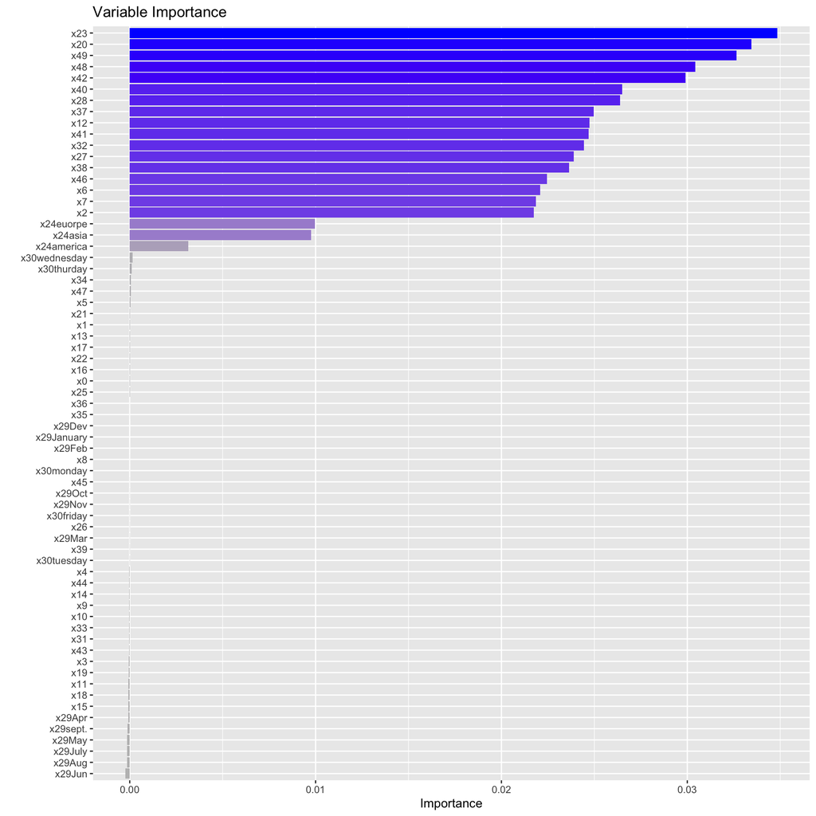

```r
# sexier importance plot
final_caret_imp.df <- as.data.frame(final_train.caret$finalModel$variable.importance)

#rownames
final_caret_imp.df$x_label <- rownames(final_caret_imp.df)

#rename column
names(final_caret_imp.df)[1] <- "x_value"


#ggplot
ggplot(final_caret_imp.df, aes(x=reorder(x_label,x_value), y=x_value,fill=x_value)) + geom_bar(stat = 'identity') + coord_flip() + ylab("Importance") + xlab("") + ggtitle("Variable Importance") + guides(fill=F) + scale_fill_gradient(low="gray", high="blue")
```

## Model 4: Forward Feed Neural Network (FFNN)

```r
#################################
### FULL MODEL: ALL VARIABLES ###
#################################

# cluster preparation for parallel CPU
library(parallel)
library(doParallel)
cluster <- makeCluster(detectCores() - 1) # leave 1 core for OS
registerDoParallel(cluster)

ptm <- proc.time()

# training grid
nn.grid <- expand.grid(size = c(8,8), decay = c(0.05))

trainControl(
  method = "cv",
  number = 5,
  summaryFunction = twoClassSummary,
  allowParallel = T,
  classProbs = F,
  verboseIter = T,
  search = "random"
  ) -> full_nnet.grid


### NOTE: the standard formula syntax of "y ~ ." is not accepted in the neuralnet() function
## Must first create formula object then pass it to neuralnet() function

train_names <- names(final_train.df)
train_formula_nn <- as.formula(paste("y ~", paste(train_names[!train_names %in% "y"], collapse = " + ")))

# training NNET model
train(train_formula_nn,
  data = final_train.df,
  method = "nnet",
  metric = "Spec",  # "Accuracy",  # "ROC",
  trControl = full_nnet.grid,
  num.threads = (detectCores() - 1),
  preProcess = "scale",
  tuneGrid = nn.grid
) -> full_train.nnet
proc.time() - ptm
```

```
   user  system elapsed
 85.909   1.880 257.160
```

```r
### SHUTDOWN CLUSTER
stopCluster(cluster)
#registerDoSEQ()
```

The AUC score for the FFNN model model is 0.8287071, which is less desirable than either of the two random forest models above.

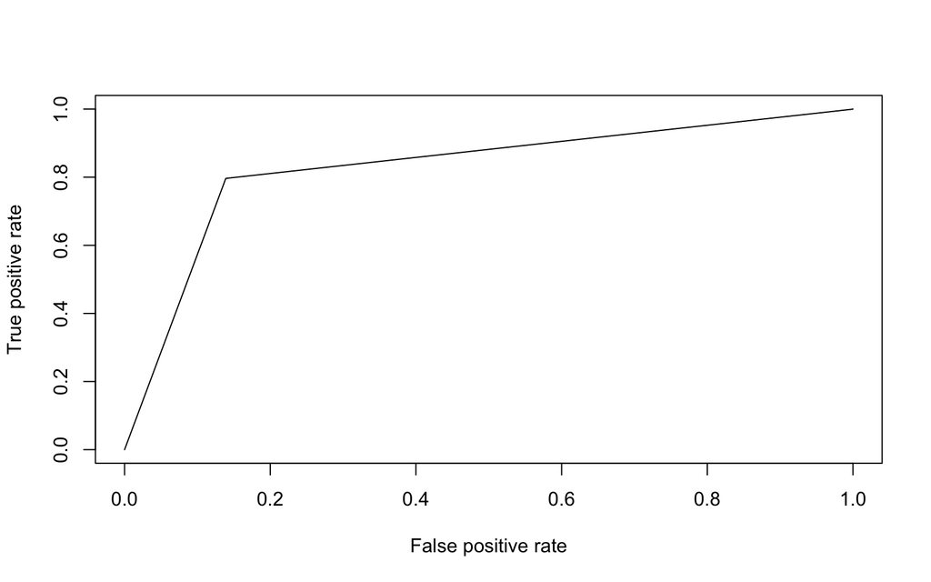

```r
# predictions
predict(full_train.nnet, final_test.df) -> full_nnet.pred

# AUC plot
# NOTE: must convert values to numeric to use function
performance(
  ROCR::prediction(
    as.numeric(full_nnet.pred),
    as.numeric(final_test.df$y)
    ),
  measure = "tpr",
  x.measure = "fpr"
) -> full_nnet.perf
plot(full_nnet.perf)
```

```r
# AUC value
print("AUC Value for this model is ")
```

```
[1] "AUC Value for this model is "
```

```r
performance(
  ROCR::prediction(
    as.numeric(full_nnet.pred),
    as.numeric(final_test.df$y)
    ),
  measure = "auc",
  )@y.values[[1]]
```

```
[1] 0.8287071
```

Per the confusion matrix, the FFNN model yielded 2,614 false negatives and 2,663 false positives, for a total cost of $1,333,630.

```r
# confusion matrix
caret::confusionMatrix(
  data = relevel(full_nnet.pred, ref = "1"),
  reference = relevel(final_test.df$y, ref = "1")
)
```

```
Confusion Matrix and Statistics

          Reference
Prediction     1     0
         1 10225  2663
         0  2614 16497

               Accuracy : 0.8351
                 95% CI : (0.831, 0.8391)
    No Information Rate : 0.5988
    P-Value [Acc > NIR] : <2e-16

                  Kappa : 0.657

 Mcnemar's Test P-Value : 0.5088

            Sensitivity : 0.7964
            Specificity : 0.8610
         Pos Pred Value : 0.7934
         Neg Pred Value : 0.8632
             Prevalence : 0.4012
         Detection Rate : 0.3195
   Detection Prevalence : 0.4028
      Balanced Accuracy : 0.8287

       'Positive' Class : 1
```

## Model 5: Forward Feed Neural Network - Important Variables

For this variation of the FFNN model we used only the most important variables as per the `ranger` random forest model.

```r
###############################################
### FFNN w/IMPORTANT VARIABLES FROM RANGER ###
##############################################


# cluster preparation for parallel CPU
library(parallel)
library(doParallel)
cluster <- makeCluster(detectCores() - 1) # leave 1 core for OS
registerDoParallel(cluster)

ptm <- proc.time()

# training grid
nn.grid <- expand.grid(size = c(7,7), decay = c(0.01))

trainControl(
  method = "cv",
  number = 5,
  summaryFunction = twoClassSummary,
  allowParallel = T,
  classProbs = F,
  verboseIter = T,
  search = "random"
  ) -> final_nnet.grid

# formula
train_formula <- as.formula(y ~ x23 + x49 + x20 + x48 + x42 + x37 + x12 + x40 + x27 + x6 + x2 + x28 + x41 + x38 + x7 + x46 + x32)

# training NNET model
train(train_formula,
  data = final_train.df,
  method = "nnet",
  metric = "Spec",  # "ROC",
  trControl = final_nnet.grid,
  num.threads = (detectCores() - 1),
  preProcess = "scale",
  tuneGrid = nn.grid
) -> final_train.nnet
proc.time() - ptm
```

```
   user  system elapsed
 26.716   0.336  91.810
```

```r
### SHUTDOWN CLUSTER
stopCluster(cluster)
#registerDoSEQ()
```

The AUC score for the FFNN model with important variables is 0.8469703.

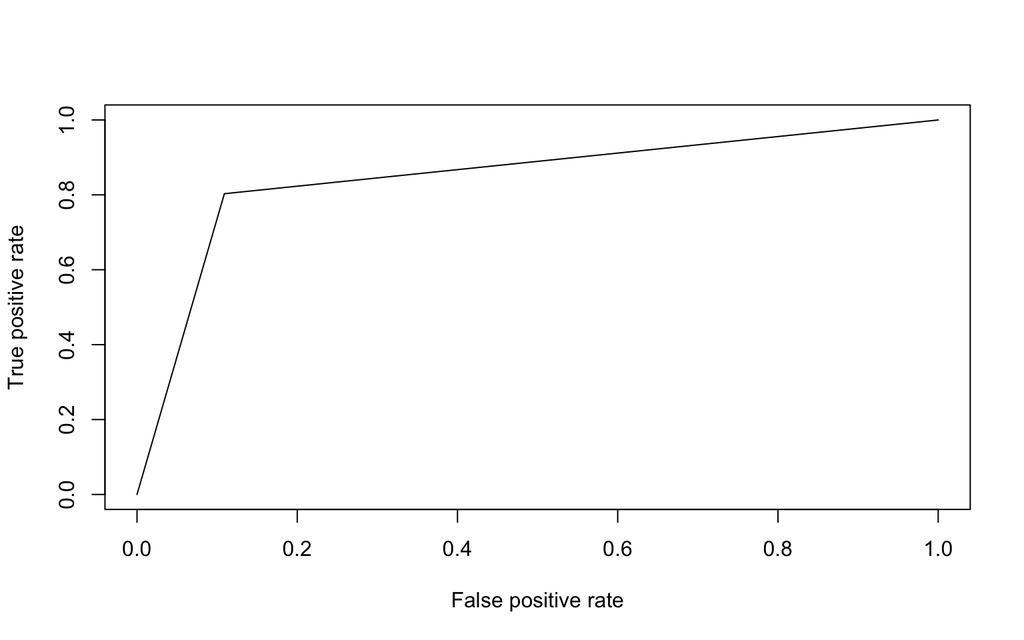

```r
# evaluate model with test predictions
predict(final_train.nnet, final_test.df) -> final_nnet.pred

# AUC plot
# NOTE: must convert values to numeric to use function
performance(
  ROCR::prediction(
    as.numeric(final_nnet.pred),
    as.numeric(final_test.df$y)
    ),
  measure = "tpr",
  x.measure = "fpr"
) -> final_nnet.perf
plot(final_nnet.perf)
```

```r
# AUC value
print("AUC Value for this model is ")
```

```
[1] "AUC Value for this model is "
```

```r
performance(
  ROCR::prediction(
    as.numeric(final_nnet.pred),
    as.numeric(final_test.df$y)
    ),
  measure = "auc",
  )@y.values[[1]]
```

```
[1] 0.8469703
```

Per the confusion matrix, the FFNN model using the most important variables yielded 2,529 false negatives and 2,090 false positives, for a total cost of $1,285,400, which is a $48,200 improvement over the full FFNN model.

```r
# confusion matrix
caret::confusionMatrix(
  data = relevel(final_nnet.pred, ref = "1"),
  reference = relevel(final_test.df$y, ref = "1")
)
```

```
Confusion Matrix and Statistics

          Reference
Prediction     1     0
         1 10310  2090
         0  2529 17070

               Accuracy : 0.8557
                 95% CI : (0.8518, 0.8595)
    No Information Rate : 0.5988
    P-Value [Acc > NIR] : < 2.2e-16

                  Kappa : 0.6979

 Mcnemar's Test P-Value : 1.159e-10

            Sensitivity : 0.8030
            Specificity : 0.8909
         Pos Pred Value : 0.8315
         Neg Pred Value : 0.8710
             Prevalence : 0.4012
         Detection Rate : 0.3222
   Detection Prevalence : 0.3875
      Balanced Accuracy : 0.8470

       'Positive' Class : 1
```

## Conclusion

Table 1: Model Performance

[output not shown]

Christian Nava, Jeremy Otsap, Martin Garcia, Michael Catalano,

8/1/2020